# 9.4 Principal Component Analyses (PCA) | Statistics for Linguists using R - Quantitative and qualitative approaches

## 9.4 Principal Component Analyses (PCA)

For this next step, we use PCA to first reduce dimensionality. PCA works by choosing a maximum number of dimensions that is always close to number of predictors - 1. Then you need to make decisions on how many dimensions to retain (usually, those with a variance explained of 5% and above).

The dimensions are all decorrelated from each other.

### 9.4.1 Model specification

We use the package `FactoMineR` to run our PCA. We use all acoustic measures as predictors and our qualitative variable as the `context`.

```r
### below to change maximum overlap for the PCA, Cluster and MDS to draw all information.
options(ggrepel.max.overlaps = Inf)
```

```r
dfPharPCA <- dfPharV2 %>%
  column_to_rownames(var = "contextN")
dfPharPCA
```

```
##             context      CPP    Energy     H1A1c        H1A2c         H1A3c
## G_01       Guttural 23.53283 22.753333 15.162000 16.037000000  -3.297166667
## G_02       Guttural 25.71500 22.831167 13.196333 11.624000000  -5.915833333
## G_03       Guttural 19.61600  9.157167 16.547667 18.548833330   0.603666667
## G_04       Guttural 23.59050 17.183000 15.999167 20.108000000  -7.629833333
## G_05       Guttural 26.01967 15.581667 14.545167 14.597000000  -6.729000000
## G_06       Guttural 24.52800 14.442500 16.604833 16.568000000  -5.458833333
## G_07       Guttural 23.05033 18.636167 14.983167 15.770666670  -5.939333333
## G_08       Guttural 22.23483  9.035333 17.085000 18.395500000   2.102500000
## G_09       Guttural 28.40900 25.507667 12.531167 15.144500000  -3.332666667
## G_10       Guttural 28.20017 15.784833 14.676833 16.255166670  -0.052833333
## G_11       Guttural 21.94183  8.381167 15.327667 18.298333330   3.297166667
## G_12       Guttural 25.25917 16.427000 14.621500 17.851666670   2.645833333
## G_13       Guttural 26.77417 14.131167 13.043833 16.166000000  -0.003833333
## G_14       Guttural 23.54400  9.209167 15.923000 18.273333330   6.712333333
## G_15       Guttural 26.10400 13.204667 17.032167 15.247833330   9.653666667
## G_16       Guttural 24.04650 17.796833 15.422000 15.311833330  12.995166670
## G_17       Guttural 26.85900 16.828833 16.779167 16.698666670   7.156833333
## G_18       Guttural 28.38967 12.386833 17.686167 18.283500000   9.034500000
## G_19       Guttural 27.74700 12.045167 17.961167 18.893000000  10.526833330
## G_20       Guttural 27.72100 17.095500 18.564333 17.503000000   4.353333333
## G_21       Guttural 23.99033  9.960667 14.002333 12.434333330   2.048833333
## G_22       Guttural 24.98067  6.865000  8.899500 11.032666670  12.913000000
## G_23       Guttural 22.88400  6.956667  8.780000 10.761166670   8.546833333
## G_24       Guttural 27.01567  4.675500 13.081500  8.753833333   4.991166667
## G_25       Guttural 25.42633  5.078000 12.522833 10.404166670   0.702500000
## G_26       Guttural 26.21867  3.023833 15.719167 15.716166670  11.879666670
## G_27       Guttural 26.66750  8.298000 13.625833 17.810333330  -4.839833333
## G_28       Guttural 26.55600  6.984500 12.874333 14.356000000   1.241000000
## G_29       Guttural 24.96783  9.881167 13.538167 17.752666670   5.358833333
## G_30       Guttural 27.32883  8.930000 11.241333  2.697666667   4.946666667
## G_31       Guttural 25.13367  5.666667 11.121500  6.970833333   2.848000000
## G_32       Guttural 22.07817  6.520833  8.810167  6.967666667   4.062166667
## G_33       Guttural 26.69700  8.279500 12.228667 13.083333330  -1.072833333
## G_34       Guttural 27.88283  6.787167 13.108000  9.650333333   3.450000000
## G_35       Guttural 26.94067  9.193333 11.172167 14.366333330   3.103000000
## G_36       Guttural 27.27650  3.635833 12.690667 13.933166670   7.320666667
## G_37       Guttural 27.37950  3.656667 13.509000 10.092166670   3.168833333
## G_38       Guttural 28.56267  3.316500 14.945167 12.151833330   3.007166667
## G_39       Guttural 28.33483  5.217833 11.892333  9.054833333   5.095666667
```

[output cut: 1557 more lines]

```
## NG_208 2.0752244 2.6765754   0.16550000 -24.1613333 -24.326833330
## NG_209 1.9477910 2.7006057   1.84333333 -17.7805000 -19.623833330
## NG_210 1.8930054 2.6490753   2.69433333 -19.3576667 -22.052000000
## NG_211 1.2586754 2.5936981  -1.50500000 -25.5440000 -24.039000000
## NG_212 1.1898659 2.6352857  -0.64916667 -24.5226667 -23.873500000
## NG_213 1.2297406 2.6276217   0.67066667 -24.0013333 -24.672000000
## NG_214 1.2920648 2.5843075   1.11983333 -22.4265000 -23.546333330
## NG_215 1.4312453 2.6001104   2.71800000 -19.0253333 -21.743333330
## NG_216 1.4164609 2.6278478   6.66733333 -18.8476667 -25.515000000
## NG_217 1.4023787 2.6060187   4.55266667 -22.8726667 -27.425333330
## NG_218 1.8186648 2.5649800   7.28300000 -17.8055000 -25.088500000
## NG_219 1.6490923 2.6160705   5.75100000 -18.3648333 -24.115833330
## NG_220 2.0113137 2.6604471   1.12550000 -19.2691667 -20.394666670
## NG_221 1.8697238 2.6208004   3.03883333 -18.5955000 -21.634333330
## NG_222 1.7939113 2.6886140   4.76550000 -20.3470000 -25.112500000
```

```r
pcaDat1 <- PCA(dfPharPCA,
               quali.sup = 1,
               graph = TRUE,
               scale.unit = TRUE, ncp = 5)
```

[figure not shown]

### 9.4.2 Scree plot

This shows the percent explained variance for our PCs. This is equivalent to the normalized eigenvalues of the covariance matrix used in PCA. Traditionally, any PC that explained 5% or above of the variance can be retained. In our example below, we know that the first 2 dimensions explain most of the variance, with the third dimension contributing more than 10%.

```r
fviz_eig(pcaDat1)
```

[figure not shown]

### 9.4.3 Results

#### 9.4.3.1 Summary of results

Based on the summary of results, we observe that the first 5 dimensions account 88.3% of the variance in the data; each contribute individually to more than 5% of the variance (the fifth is at 4.97%!).

```r
summary(pcaDat1)
```

```
##
## Call:
## PCA(X = dfPharPCA, scale.unit = TRUE, ncp = 5, quali.sup = 1,
##      graph = TRUE)
##
##
## Eigenvalues
##                        Dim.1   Dim.2   Dim.3   Dim.4   Dim.5   Dim.6   Dim.7
## Variance               8.660   5.868   2.625   2.017   1.143   0.749   0.549
## % of var.             37.652  25.512  11.412   8.769   4.972   3.259   2.388
## Cumulative % of var.  37.652  63.164  74.577  83.346  88.317  91.576  93.964
##                        Dim.8   Dim.9  Dim.10  Dim.11  Dim.12  Dim.13  Dim.14
## Variance               0.419   0.284   0.220   0.141   0.110   0.087   0.057
## % of var.              1.820   1.235   0.957   0.612   0.479   0.377   0.246
## Cumulative % of var.  95.784  97.019  97.976  98.588  99.067  99.444  99.690
##                       Dim.15  Dim.16  Dim.17  Dim.18  Dim.19  Dim.20  Dim.21
## Variance               0.032   0.015   0.012   0.008   0.002   0.001   0.000
## % of var.              0.138   0.066   0.054   0.036   0.010   0.006   0.000
## Cumulative % of var.  99.828  99.894  99.948  99.984  99.994 100.000 100.000
##                       Dim.22  Dim.23
## Variance               0.000   0.000
## % of var.              0.000   0.000
## Cumulative % of var. 100.000 100.000
##
## Individuals (the 10 first)
##                  Dist    Dim.1    ctr   cos2    Dim.2    ctr   cos2    Dim.3
## G_01         |  6.871 | -4.756  0.650  0.479 | -2.241  0.213  0.106 |  2.535
## G_02         |  5.728 | -3.279  0.309  0.328 | -1.258  0.067  0.048 |  2.704
## G_03         |  6.642 | -5.052  0.733  0.578 | -1.599  0.108  0.058 |  1.378
## G_04         |  6.294 | -3.773  0.409  0.359 | -3.037  0.391  0.233 |  1.921
## G_05         |  4.944 | -3.009  0.260  0.370 | -1.892  0.152  0.147 |  1.708
## G_06         |  5.988 | -3.773  0.409  0.397 | -2.018  0.173  0.114 |  2.051
## G_07         |  6.381 | -4.450  0.569  0.486 | -2.262  0.217  0.126 |  2.250
## G_08         |  5.149 | -4.092  0.481  0.632 | -1.213  0.062  0.055 |  1.609
## G_09         |  6.178 | -3.696  0.392  0.358 | -1.742  0.129  0.079 |  2.580
## G_10         |  4.011 | -2.676  0.206  0.445 | -1.115  0.053  0.077 |  1.897
##                 ctr   cos2
## G_01          0.609  0.136 |
## G_02          0.693  0.223 |
## G_03          0.180  0.043 |
```

[output cut: 24 more lines]

```
## H1A2c         0.022 |
## H1A3c         0.000 |
## H1H2c         0.006 |
## H2H4c         0.016 |
## H2KH5Kc       0.347 |
## H42Kc         0.044 |
## HNR05         0.088 |
##
## Supplementary categories
##                  Dist    Dim.1   cos2 v.test    Dim.2   cos2 v.test    Dim.3
## Non-Guttural |  0.713 |  0.116  0.026  0.875 |  0.561  0.618  5.147 | -0.207
## Guttural     |  0.880 | -0.143  0.026 -0.875 | -0.691  0.618 -5.147 |  0.256
##                cos2 v.test
## Non-Guttural  0.085 -2.846 |
## Guttural      0.085  2.846 |
```

#### 9.4.3.2 Contribution of predictors and groups

Below, we look at the contributions of the main 5 dimensions.

```r
dimdesc(pcaDat1, axes = 1:5, proba = 0.05)
```

```
## $Dim.1
##
## Link between the variable and the continuous variables (R-square)
## =================================================================================
##         correlation       p.value
## F0Bark    0.9471236 1.429483e-199
## HNR25     0.9346079 1.131178e-181
## soe       0.9284685 3.755961e-174
## HNR35     0.9248084 5.569479e-170
## HNR05     0.9108131 8.807770e-156
## HNR15     0.8954107 1.220387e-142
## H1H2c     0.8656253 3.099776e-122
## H1A1c     0.6709032  6.724616e-54
## CPP       0.5236515  1.098679e-29
## H1A2c    -0.1137865  2.250563e-02
## H2KH5Kc  -0.1164455  1.952233e-02
## H1A3c    -0.2366755  1.595378e-06
## H42Kc    -0.3800759  2.903273e-15
## Z1mnZ0   -0.4268127  3.150556e-19
## A1mnA2   -0.4963663  2.148508e-26
## H2H4c    -0.5281247  2.967330e-30
## Energy   -0.5712695  3.377633e-36
## A1mnA3   -0.6262636  3.576749e-45
## SHR      -0.6393517  1.394910e-47
##
## $Dim.2
##
## Link between the variable and the continuous variables (R-square)
## =================================================================================
##         correlation       p.value
## A2mnA3    0.9488972 1.862448e-202
## Z2mnZ1    0.8611635 1.326843e-119
## H42Kc     0.8091541  2.107251e-94
## H1A3c     0.5906500  3.640784e-39
## A1mnA3    0.4113725  7.545605e-18
## CPP       0.2355070  1.801379e-06
## HNR15     0.2195716  8.870306e-06
## Z4mnZ3    0.1585383  1.427779e-03
## H2H4c     0.1158268  2.018384e-02
## Energy   -0.1267753  1.095302e-02
```

[output cut: 89 more lines]

```
## $Dim.5
##
## Link between the variable and the continuous variables (R-square)
## =================================================================================
##        correlation      p.value
## H2H4c   0.67917208 1.098695e-55
## CPP     0.58268792 6.373444e-38
## HNR15   0.24837172 4.569075e-07
## HNR25   0.18018109 2.821810e-04
## HNR05   0.16392456 9.710453e-04
## HNR35   0.15076346 2.439664e-03
## SHR     0.09962685 4.590553e-02
## F0Bark -0.13227856 7.916814e-03
## H42Kc  -0.15107672 2.388688e-03
## H1H2c  -0.33610840 4.506374e-12
```

#### 9.4.3.3 Contribution of variables

##### 9.4.3.3.1 Dimension 1

```r
fviz_contrib(pcaDat1, choice = "var", axes = 1, top = 10)
```

[figure not shown]

##### 9.4.3.3.2 Dimension 2

```r
fviz_contrib(pcaDat1, choice = "var", axes = 2, top = 10)
```

[figure not shown]

##### 9.4.3.3.3 Dimension 3

```r
fviz_contrib(pcaDat1, choice = "var", axes = 3, top = 10)
```

[figure not shown]

##### 9.4.3.3.4 Dimension 4

```r
fviz_contrib(pcaDat1, choice = "var", axes = 4, top = 10)
```

[figure not shown]

##### 9.4.3.3.5 Dimension 5

```r
fviz_contrib(pcaDat1, choice = "var", axes = 5, top = 10)
```

[figure not shown]

### 9.4.4 Plots

#### 9.4.4.1 Default plots

##### 9.4.4.1.1 PCA Individuals

```r
fviz_pca_ind(pcaDat1, col.ind = "cos2",
             gradient.cols = c("#00AFBB", "#E7B800", "#FC4E07"),
             repel = FALSE ## Avoid text overlapping (slow if many points)
             )
```

[figure not shown]

##### 9.4.4.1.2 PCA Biplot 1:2

```r
fviz_pca_biplot(pcaDat1, repel = FALSE, habillage = dfPharPCA$context, addEllipses = TRUE, title = "Biplot")
```

[figure not shown]

##### 9.4.4.1.3 PCA Biplot 3:4

```r
fviz_pca_biplot(pcaDat1, axes = c(3, 4), repel = FALSE, habillage = dfPharPCA$context, addEllipses = TRUE, title = "Biplot")
```

[figure not shown]

#### 9.4.4.2 Clustering

```r
fviz_pca_ind(pcaDat1,
             label = "none", ## hide individual labels
             habillage = dfPharPCA$context, ## color by groups
             addEllipses = TRUE ## Concentration ellipses
             )
```

[figure not shown]

#### 9.4.4.3 3-D By Groups

```r
coord <- pcaDat1$quali.sup$coord[1:2,0]
coord
```

```
##
## Non-Guttural
## Guttural
```

```r
#
with(pcaDat1, {
  s3d <- scatterplot3d(pcaDat1$quali.sup$coord[,1], pcaDat1$quali.sup$coord[,2], pcaDat1$quali.sup$coord[,3],        ## x y and z axis
                       color=c("blue", "red"), pch=19,        ## filled blue and red circles
                       type="h",                    ## vertical lines to the x-y plane
                       main="PCA 3-D Scatterplot",
                       xlab="Dim1(37.7%)",
                       ylab="",
                       zlab="Dim3(11.4%)",
                       #xlim = c(-1.5, 1.5), ylim = c(-1.5, 1.5), zlim = c(-0.8, 0.8)
)
  s3d.coords <- s3d$xyz.convert(pcaDat1$quali.sup$coord[,1], pcaDat1$quali.sup$coord[,2], pcaDat1$quali.sup$coord[,3]) ## convert 3D coords to 2D projection
  text(s3d.coords$x, s3d.coords$y,             ## x and y coordinates
       labels=row.names(coord), col = c("blue", "red"),              ## text to plot
       cex=1, pos=4)           ## shrink text 50% and place to right of points)
})
dims <- par("usr")
x <- dims[1]+ 0.8*diff(dims[1:2])
y <- dims[3]+ 0.08*diff(dims[3:4])
text(x, y, "Dim2(25.5%)", srt = 25,col="black")
```

[figure not shown]

Using the PCA approach allowed us to separate the two contexts and showed that we can use up to five dimensions to explain the results.

### 9.4.5 Advanced

#### 9.4.5.1 Investigate

The `Investigate` function allows to obtain an automatic analysis of the PCA an automatic analysis of the PCA results. It will generate an HTML report that we can import below. The report includes the PCA results, detection of outliers, evaluation of inertia (or % cumulative variance explained), in addition to a description of the top significant dimensions. It also provides a classification via clustering of the predictors, and an evaluation of the results. It should be noted that “*This interpretation of the results was carried out automatically, it cannot match the quality of a personal interpretation*”

```r
Investigate(pcaDat1, file = "outputs/Investigate.Rmd", language = "en")
```

```
## -- creation of the .Rmd file (time spent : 0s) --
##
## -- detection of outliers (time spent : 0.01s) --
## 0 outlier(s) terminated
##
## -- analysis of the inertia (time spent : 0.03s) --
## 4 component(s) carrying information : total inertia of 83.3%
##
## -- components description (time spent : 4.4s) --
## plane 1:2
## plane 3:4
##
## -- classification (time spent : 4.92s) --
## 3 clusters
##
## -- annexes writing (time spent : 5.1s) --
##
## -- saving data (time spent : 5.25s) --
##
## -- outputs compilation (time spent : 5.25s) --
```

```
## -- task completed (time spent : 13.33s) --
## This interpretation of the results was carried out automatically,
## it cannot match the quality of a personal interpretation
```

```r
htmltools::includeHTML("outputs/Investigate.html")
```

# Principal Component Analysis

Dataset dfPharPCA

This dataset contains 402 individuals and 24 variables, 1 qualitative variable is considered as illustrative.

### 1. Study of the outliers

The analysis of the graphs does not detect any outlier.

### 2. Inertia distribution

The inertia of the first dimensions shows if there are strong relationships between variables and suggests the number of dimensions that should be studied.

The first two dimensions of analyse express **63.16%** of the total dataset inertia ; that means that 63.16% of the individuals (or variables) cloud total variability is explained by the plane. This percentage is relatively high and thus the first plane well represents the data variability. This value is strongly greater than the reference value that equals **12.78%**, the variability explained by this plane is thus highly significant (the reference value is the 0.95-quantile of the inertia percentages distribution obtained by simulating 1014 data tables of equivalent size on the basis of a normal distribution).

From these observations, it should be better to also interpret the dimensions greater or equal to the third one.

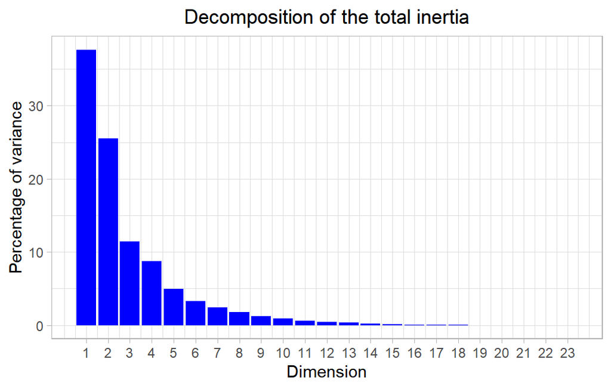

**Figure 2 - Decomposition of the total inertia**

An estimation of the right number of axis to interpret suggests to restrict the analysis to the description of the first 4 axis. These axis present an amount of inertia greater than those obtained by the 0.95-quantile of random distributions (83.35% against 24.26%). This observation suggests that only these axis are carrying a real information. As a consequence, the description will stand to these axis.

### 3. Description of the plane 1:2

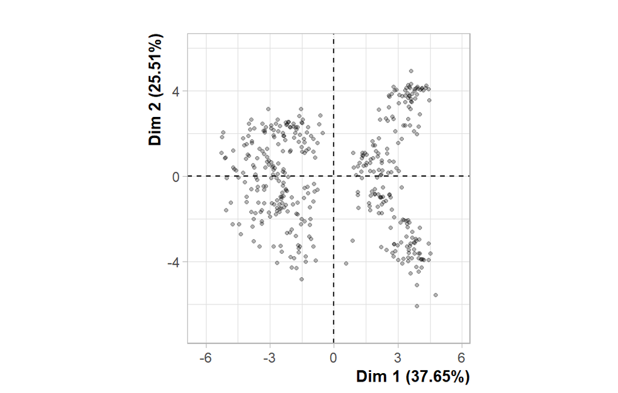

**Figure 3.1 - Individuals factor map (PCA)** *The labeled individuals are those with the higher contribution to the plane construction.*

The Wilks test p-value indicates which variable factors are the best separated on the plane (i.e. which one explain the best the distance between individuals).

```
##      context
## 7.957422e-07
```

There only is one possible qualitative variable to illustrate the distance between individuals : *context*.

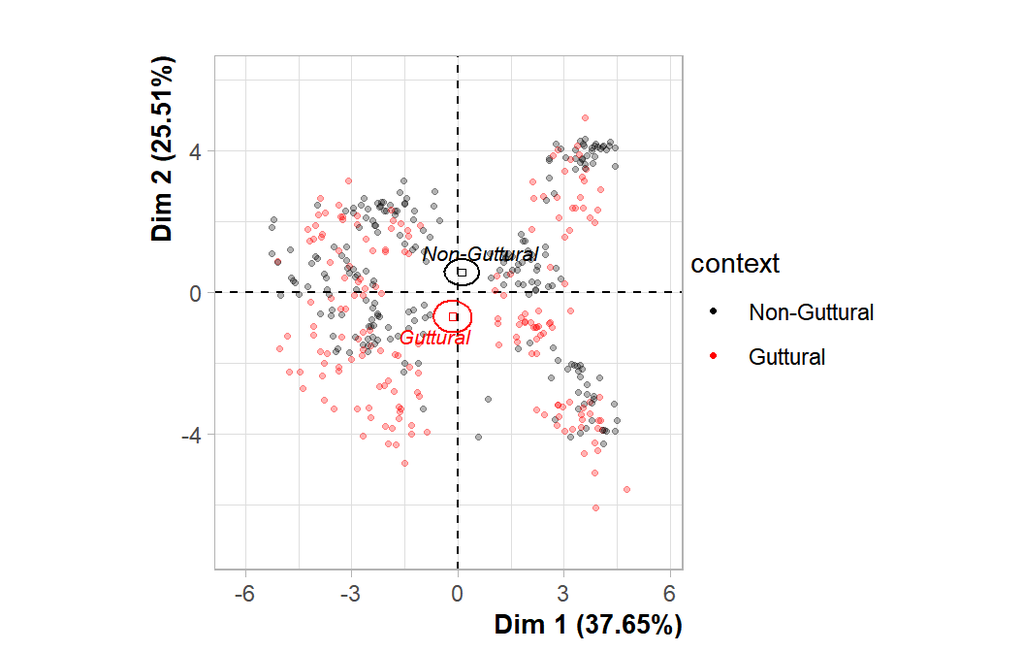

**Figure 3.2 - Individuals factor map (PCA)** *The labeled individuals are those with the higher contribution to the plane construction.* *The individuals are coloured after their category for the variable* context.

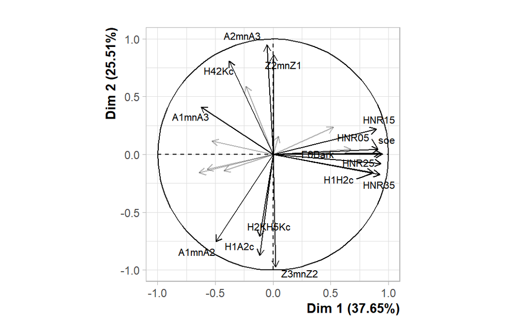

**Figure 3.3 - Variables factor map (PCA)** *The labeled variables are those the best shown on the plane.*

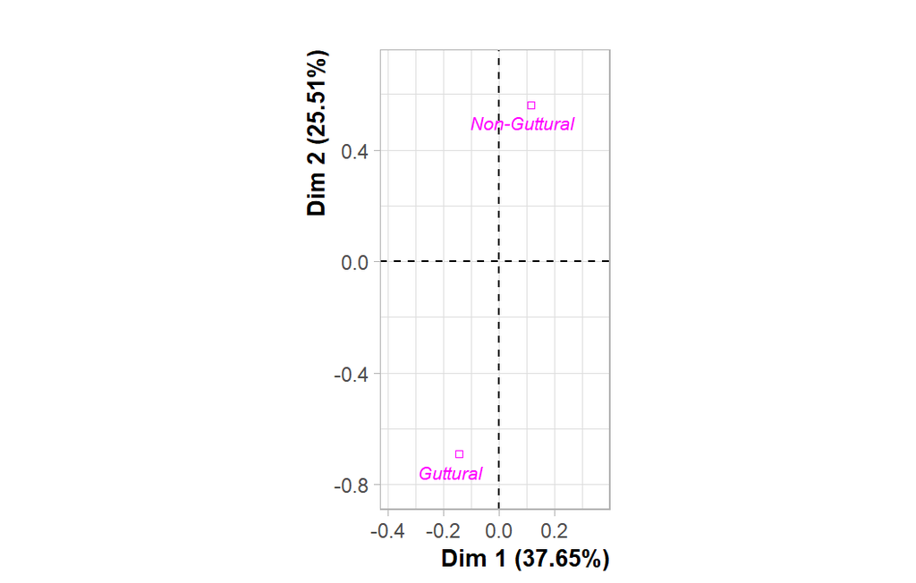

**Figure 3.4 - Qualitative factor map (PCA)** *The labeled factors are those the best shown on the plane.*

The **dimension 1** opposes individuals characterized by a strongly positive coordinate on the axis (to the right of the graph) to individuals characterized by a strongly negative coordinate on the axis (to the left of the graph).

The group 1 (characterized by a positive coordinate on the axis) is sharing :

- high values for variables like *Z2mnZ1*, *A2mnA3*, *HNR15*, *CPP*, *HNR05*, *soe*, *F0Bark*, *H1A1c*, *HNR25* and *H42Kc* (variables are sorted from the strongest).
- low values for the variables *A1mnA2*, *H1A2c*, *Z3mnZ2*, *H2KH5Kc*, *Z1mnZ0*, *SHR*, *Energy* and *H2H4c* (variables are sorted from the weakest).

The group 2 (characterized by a positive coordinate on the axis) is sharing :

- high values for variables like *Z3mnZ2*, *H1H2c*, *H2KH5Kc*, *HNR35*, *H1A2c*, *F0Bark*, *HNR25*, *soe*, *HNR05* and *A1mnA2* (variables are sorted from the strongest).
- low values for the variables *H42Kc*, *A2mnA3*, *Z2mnZ1*, *H2H4c*, *A1mnA3*, *H1A3c*, *Energy*, *Z1mnZ0* and *SHR* (variables are sorted from the weakest).

The group 3 (characterized by a negative coordinate on the axis) is sharing :

- high values for the variables *Z1mnZ0*, *H2H4c*, *Energy*, *SHR*, *A1mnA3*, *A1mnA2*, *H42Kc*, *H1A3c* and *H1A2c* (variables are sorted from the strongest).
- low values for the variables *F0Bark*, *soe*, *HNR05*, *HNR35*, *HNR25*, *H1H2c*, *HNR15*, *H1A1c* and *CPP* (variables are sorted from the weakest).

The **dimension 2** opposes individuals characterized by a strongly positive coordinate on the axis (to the top of the graph) to individuals characterized by a strongly negative coordinate on the axis (to the bottom of the graph).

The group 1 (characterized by a positive coordinate on the axis) is sharing :

- high values for variables like *Z2mnZ1*, *A2mnA3*, *HNR15*, *CPP*, *HNR05*, *soe*, *F0Bark*, *H1A1c*, *HNR25* and *H42Kc* (variables are sorted from the strongest).
- low values for the variables *A1mnA2*, *H1A2c*, *Z3mnZ2*, *H2KH5Kc*, *Z1mnZ0*, *SHR*, *Energy* and *H2H4c* (variables are sorted from the weakest).

The group 2 (characterized by a negative coordinate on the axis) is sharing :

- high values for variables like *Z3mnZ2*, *H1H2c*, *H2KH5Kc*, *HNR35*, *H1A2c*, *F0Bark*, *HNR25*, *soe*, *HNR05* and *A1mnA2* (variables are sorted from the strongest).
- low values for the variables *H42Kc*, *A2mnA3*, *Z2mnZ1*, *H2H4c*, *A1mnA3*, *H1A3c*, *Energy*, *Z1mnZ0* and *SHR* (variables are sorted from the weakest).

### 4. Description of the plane 3:4

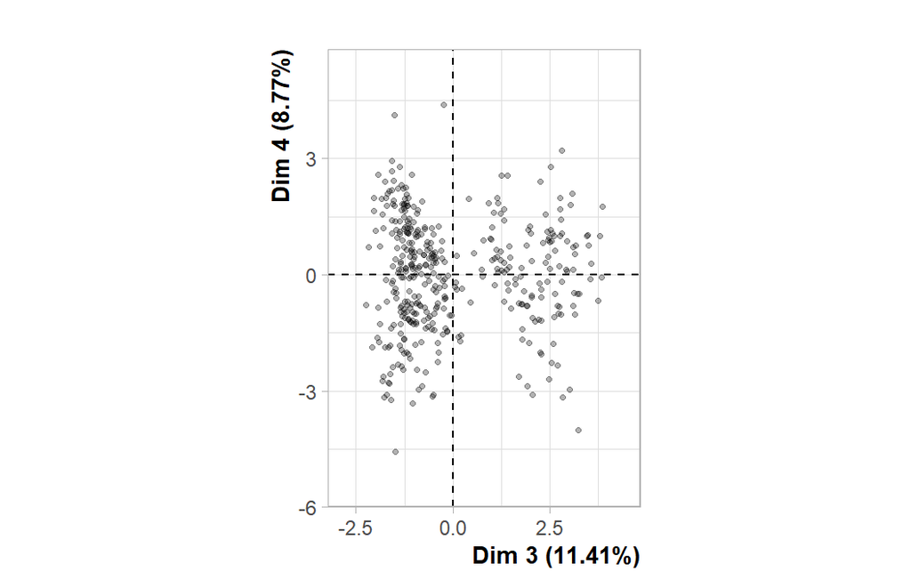

**Figure 4.1 - Individuals factor map (PCA)** *The labeled individuals are those with the higher contribution to the plane construction.*

The Wilks test p-value indicates which variable factors are the best separated on the plane (i.e. which one explain the best the distance between individuals).

```
##      context
## 1.219236e-07
```

There only is one possible qualitative variable to illustrate the distance between individuals : *context*.

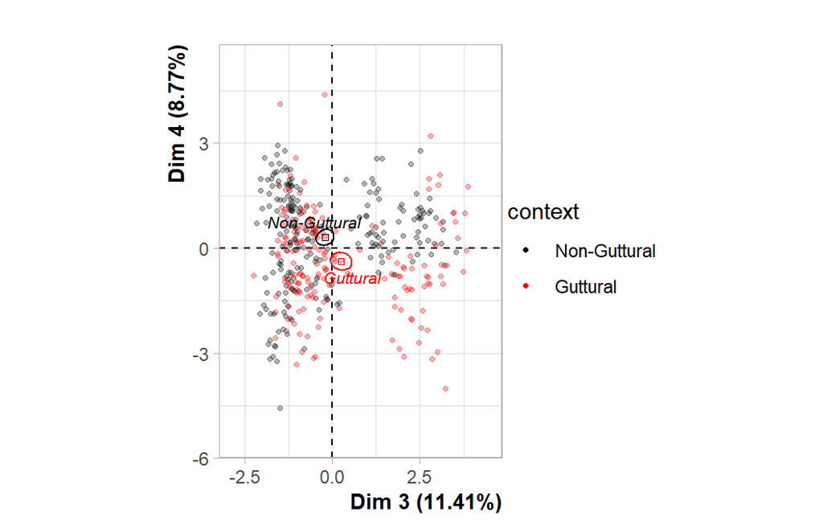

**Figure 4.2 - Individuals factor map (PCA)** *The labeled individuals are those with the higher contribution to the plane construction.* *The individuals are coloured after their category for the variable* context.

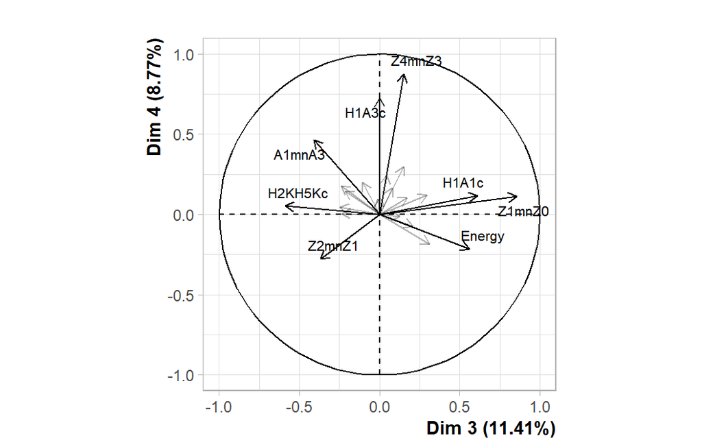

**Figure 4.3 - Variables factor map (PCA)** *The labeled variables are those the best shown on the plane.*

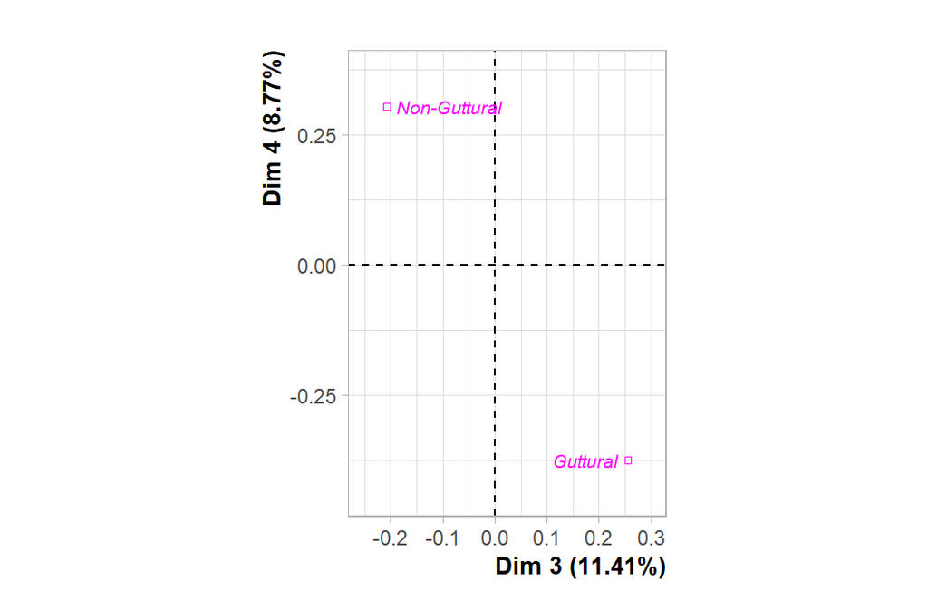

**Figure 4.4 - Qualitative factor map (PCA)** *The labeled factors are those the best shown on the plane.*

The **dimension 3** opposes individuals characterized by a strongly positive coordinate on the axis (to the right of the graph) to individuals characterized by a strongly negative coordinate on the axis (to the left of the graph).

The group 1 (characterized by a positive coordinate on the axis) is sharing :

- high values for the variables *Z1mnZ0*, *H1A1c*, *H1H2c*, *HNR05*, *F0Bark*, *CPP*, *soe*, *Energy* and *H1A2c* (variables are sorted from the strongest).
- low values for the variables *H2KH5Kc*, *A1mnA3*, *A1mnA2*, *Z2mnZ1*, *H2H4c*, *A2mnA3* and *SHR* (variables are sorted from the weakest).

The group 2 (characterized by a negative coordinate on the axis) is sharing :

- high values for the variables *A1mnA3*, *H2KH5Kc*, *A1mnA2*, *Z4mnZ3*, *H1A3c*, *Z3mnZ2*, *SHR*, *H1A2c*, *A2mnA3* and *H2H4c* (variables are sorted from the strongest).
- low values for variables like *Z1mnZ0*, *CPP*, *H1A1c*, *HNR05*, *H1H2c*, *F0Bark*, *H42Kc*, *Energy*, *soe* and *Z2mnZ1* (variables are sorted from the weakest).

The group 3 (characterized by a negative coordinate on the axis) is sharing :

- high values for the variables *Z2mnZ1*, *H42Kc* and *H2KH5Kc* (variables are sorted from the strongest).
- low values for variables like *Z4mnZ3*, *H1A2c*, *Z1mnZ0*, *H1A1c*, *H1H2c*, *H1A3c*, *F0Bark*, *HNR05*, *Z3mnZ2* and *HNR35* (variables are sorted from the weakest).

The **dimension 4** opposes individuals characterized by a strongly positive coordinate on the axis (to the top of the graph) to individuals characterized by a strongly negative coordinate on the axis (to the bottom of the graph).

The group 1 (characterized by a positive coordinate on the axis) is sharing :

- high values for the variables *A1mnA3*, *H2KH5Kc*, *A1mnA2*, *Z4mnZ3*, *H1A3c*, *Z3mnZ2*, *SHR*, *H1A2c*, *A2mnA3* and *H2H4c* (variables are sorted from the strongest).
- low values for variables like *Z1mnZ0*, *CPP*, *H1A1c*, *HNR05*, *H1H2c*, *F0Bark*, *H42Kc*, *Energy*, *soe* and *Z2mnZ1* (variables are sorted from the weakest).

The group 2 (characterized by a negative coordinate on the axis) is sharing :

- high values for the variables *Z2mnZ1*, *H42Kc* and *H2KH5Kc* (variables are sorted from the strongest).
- low values for variables like *Z4mnZ3*, *H1A2c*, *Z1mnZ0*, *H1A1c*, *H1H2c*, *H1A3c*, *F0Bark*, *HNR05*, *Z3mnZ2* and *HNR35* (variables are sorted from the weakest).

### 5. Classification

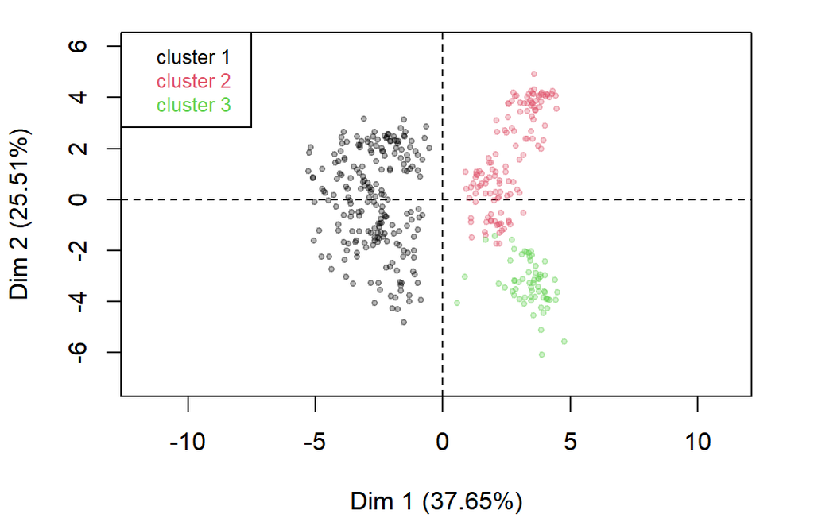

**Figure 5 - Ascending Hierarchical Classification of the individuals.** *The classification made on individuals reveals 3 clusters.*

The **cluster 1** is made of individuals sharing :

- high values for the variables *A1mnA3*, *SHR*, *A1mnA2*, *H2H4c*, *Energy*, *H42Kc*, *H2KH5Kc*, *Z1mnZ0* and *H1A3c* (variables are sorted from the strongest).
- low values for the variables *F0Bark*, *soe*, *HNR05*, *H1H2c*, *HNR35*, *HNR25*, *H1A1c*, *HNR15*, *CPP* and *Z4mnZ3* (variables are sorted from the weakest).

The **cluster 2** is made of individuals sharing :

- high values for variables like *HNR05*, *H1A1c*, *F0Bark*, *soe*, *CPP*, *HNR15*, *HNR25*, *H1H2c*, *HNR35* and *A2mnA3* (variables are sorted from the strongest).
- low values for the variables *A1mnA2*, *H2KH5Kc*, *SHR*, *Z3mnZ2*, *H1A2c*, *A1mnA3* and *Energy* (variables are sorted from the weakest).

The **cluster 3** is made of individuals sharing :

- high values for variables like *H1H2c*, *HNR35*, *Z3mnZ2*, *HNR25*, *H2KH5Kc*, *soe*, *F0Bark*, *H1A2c*, *HNR15* and *HNR05* (variables are sorted from the strongest).
- low values for the variables *H42Kc*, *H2H4c*, *A2mnA3*, *Z2mnZ1*, *A1mnA3*, *H1A3c*, *Energy*, *Z1mnZ0*, *SHR* and *CPP* (variables are sorted from the weakest).